# The Evolution of Work from Home

Mona Classen Mailin Berghaus Student ID No.: 400208802 Student ID No.: 400158172 E-mail: classen.mona@stud.hs-fresenius.de E-mail: berghaus.mailin@stud.hs-fresenius.de

Last compiled on 19 June, 2024

Abstract

In the following the impact of Covid-19 on working from home will be investigated by analyzing Barrero et al (2023) scientific approach and replicating selected graphs of the academic paper “The Evolution of Work from Home”.

# 1 Intoduction

**Relevance**

- Covid-19 had a major impact on the transition towards remote work
- To learn from a crisis such as the Corona pandemic, it is important to collect and analyze sufficient data over the relevant period
- The academic article “The Evolution of Work from Home” by Jose Maria Barrero, Nicholas Bloom, and Steven Davis (2023a) investigates why working from home arrangements persisted post-pandemic and how this shift influences the labor market, future work arrangements, employee preferences, and organizational strategies
- Barrero et al. (2023) discuss the evolution of working from home practices, highlighting the significant increase due to the COVID-19 pandemic
- The authors explain that the trend of working from home has risen slowly over time, aided by technological enhancements like remote collaboration
- The pandemic caused a massive shift to working from home

Some of their major findings are:

- The number of days that people work from home has remained high since the Covid-19 pandemic in 2020
- The rate of people working remotely is higher in the United States than in any other country
- The rates of people working from home vary by age, gender, education, parental status, industry and local population density
- This non-traditional way of working affects wages, productivity and, speed of innovation
- The shift to remote work endures thanks to adaptions in management practices and advancements in technology and products

**Objectives**

- To investigate Barrero et al. scientific approach
- To replicate parts of their work
- In this process, we analyze how the data was downloaded and compare it with the data on the website provided by Census (2023)
- The main focus is on replicating the following visuals:

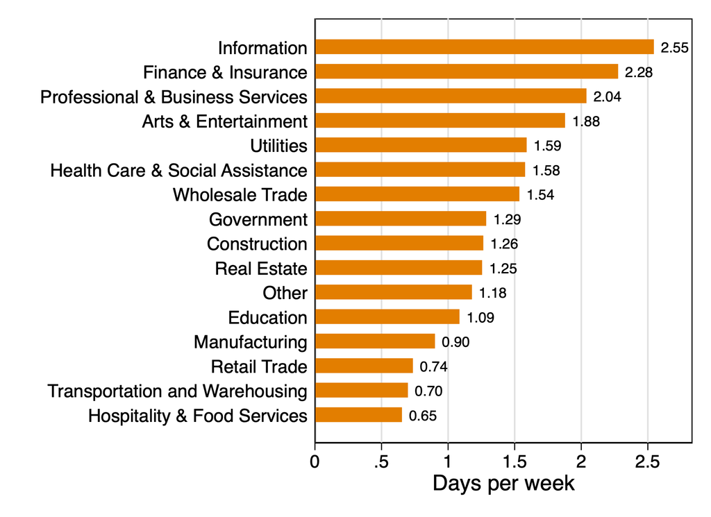

Fig. 2: US Work-from-Home Rates by Industry Sector in 2023, Employees Who Work Five or More Days per Week (Barrero et al., 2023, p. 29).

The grapgh shows mean values for the number of full days remote work, by employees aged 20-64, who worked five or more days in the period from January till June 2023

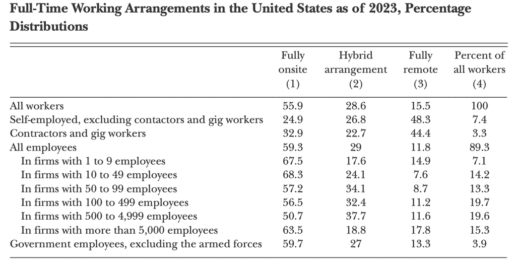

Tab. 1: Full-Time Working Arrangements in the United States as of 2023, Percentage Distributions (Barrero et al., 2023, p. 58)

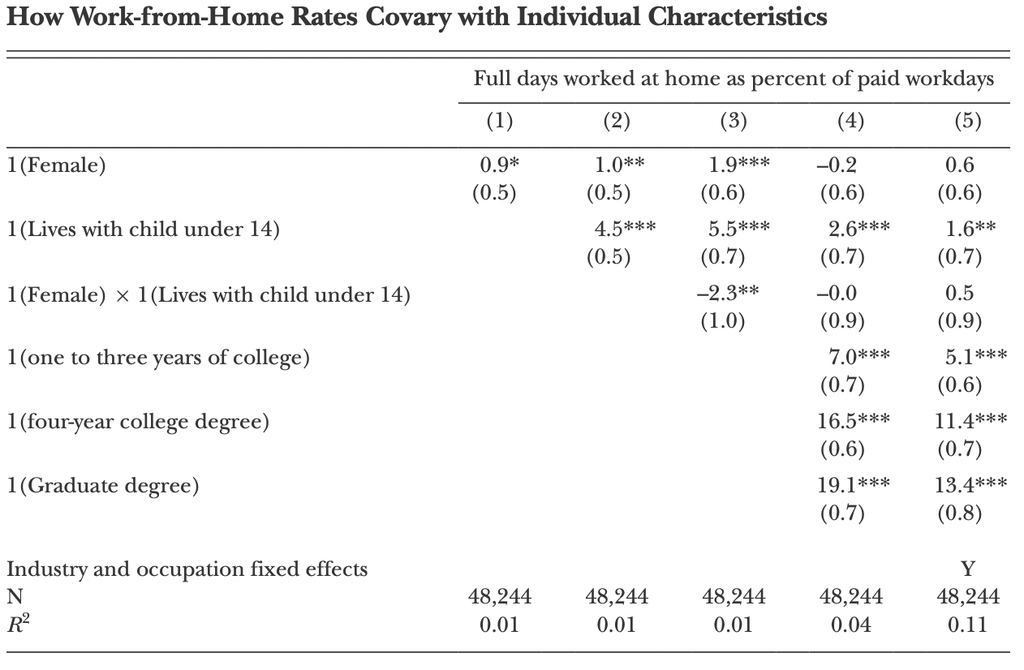

Tab. 2: How Work-from-Home Rates Covary with Individual Characteristics (Barrero et al., 2023, p. 55)

**Replication**

- The programming language of the replication package is “STATA”
- To replicate the paper, the code must be translated into “R” language.
- The paper has not yet been replicated in “R”
- For the set up of the data, the data must be read in correctly, transformed and cleaned.
- The replication package also provides edited data sets. For the replication of the figures the cleaned data set will be used.

**Analyzing the Database**

- An important step is to analyze the database
- For this purpose, the publicly available data was downloaded and compared with the data set from the Replication Package
- The authors used multiple surveys for their data. These data sets were combined to analyze the shift to working from home and its economic implications:
1. Survey of Working Arrangements and Attitudes (Barrero et al. 2023b)

The data sets must be downloaded by going to http:\\www.wfhresearch.com\\data-restrict selecting

- Raw data from the SWAA that does not impose an earnings requirement ./Data/Raw Data/ SWAA - May2020 to August 2023 Release /WFHdata_August23_noincreq.csv
- Raw data from the SWAA that does impose an earnings requirement ./Data/Raw Data/ SWAA - May2020 to August 2023 Release /WFHdata_August23.csv
- Register on the website to access data older than 2023
- Error message displayed after account creation: data does not exist
- Type in the name of the data set again to retrieve the data
- A comparison of the data within the replication package and the data from the website revealed that the data sets appear to be identical
- Slight differences in values for 2023-2024 data
2. Personal Consumption Expenditures Deflator (U.S. Bureau of Economic Analysis, 2023):
3. American Time Use Survey (Flood et al., 2023)
4. American Heritage Time Use Study (Fisher et al., 2018)
5. Census Household Pulse Survey (U.S. Bureau of Census, 2023)

**Replication Package**

- Replication package consists of six data sets in various file formats that come in a “data” folder
- All files are publicly available
- “Master.do” file that explains the overall structure of the replication package
- “Figure.do” files explain how the five graphs in the paper were generated
- “Table.do” provides the code to create the tables
- Before replicating the graphs in R, it is important to understand the steps in the setup.do file
- This file explains how the data needs to be edited in order to replicate the graph

# 2 Replication

- Open a new script and set your working directory
- Clear the environment
- Download the replication package from Association (2023)
- The data comes in a zip file
- Unzip the files before reading in the data
- Double-check the unzipped data set for errors
- Install and load the haven and tidyverse packages to import .dta files
- To import .dta files into R, you need to install and load the haven package as well as the tidyverse package. The data sets can then be imported using the “import data set” function
- To import .xls files, you can use the read_excel() function from the readxl package
- Base R can be used to read in .csv files
- Once you have imported the data, you can get a brief summary of the data

## 2.1 The Report

Figure 2 shows the US work-from-home rates by industry sector of employees who have worked five days or more per week.

To replicate figure 2, the WFHdata_noincreq data must be loaded. First, the “date” variable must be converted.

In the next step, the data set is filtered. To filter the data, use the filter() function as part of the dplyr package: - work_alldays_mat is greater than or equal to 5 - workstatus_current_new is equal to 1 - self_employment is less than or equal to 2 - grass_color_attnfull is either 2, 3, or missing - cities_attn is 33 or missing - sum3plus4 is 7 or missing.

```r
#set the working directory
setwd("~/datasciencemonamailin"")

#clear environment
rm(list = ls())

# install.packages('haven')
# install.packages('readr')
# install.packages('tidyverse')
# install.packages('tsibble')
# install.packages('dplyr')
# install.packages('tinytex')
# install.packages("bookdown")
# install.packages("devtools")
# install.packages("rmarkdown")

library(haven)
library(readr)

library(tidyverse)
library(tsibble)
library(dplyr)
library(tinytex)
library(bookdown)
library(devtools)
library(rmarkdown)

#read in the data using the setup.do file
#use the created data to replicate figure 2
#Figure 2
#create a data frame using WFHdata_noincreq, filter data frame
WFHdata_noincreq_fromCSV <- read_dta("replicationpackage/Evolution of WFH Replication/Data/Created/WFHdatanoincreqfromCSV.dta")

# Convert date column to Date format using a specific date range
df <- WFHdata_noincreq_fromCSV_figure2 <- WFHdata_noincreq_fromCSV %>%
  select(date)
head(df$date)
df$date <- as.Date(df$date)
head(df$date)

#Filter Data
WFHdata_noincreq_fromCSV_filtered <- WFHdata_noincreq_fromCSV %>%
  filter(work_alldays_mat >= 5 & workstatus_current_new == 1) %>%
  filter(self_employment <= 2) %>%
filter((grass_color_attnfull == 2 | grass_color_attnfull == 3 | is.na(grass_color_attnfull)) &
         (cities_attn == 33 | is.na(cities_attn)) &
         (sum3plus4 == 7 | is.na(sum3plus4)))

# Calculate Mean WFH Days by Industry, Excluding Certain Industries for the graph
WFHdata_noincreq_fromCSV_filtered  <- WFHdata_noincreq_fromCSV_filtered  %>%
  filter(work_industry != 10 & work_industry != 1)

industry_means <- WFHdata_noincreq_fromCSV_filtered  %>%
  group_by(work_industry) %>%
  summarise(mean_wfhdays = weighted.mean(work_wfhdays_mat, cratio100, na.rm = TRUE)) %>%
  arrange(desc(mean_wfhdays))

# Create a horizontal bar plot
# install.packages("ggplot2")
library(ggplot2)

# ggplot(mean_by_industry, aes(x = reorder(work_industry, -mean_work_wfhdays_mat), y = mean_work_wfhdays_mat)) +
#   geom_bar(stat = "identity", fill = "darkorange") +
#   labs(x = "Industry", y = "Days per week", title = "Current working from home: All wage and salary employees") +
#   theme_minimal() +
#   theme(axis.text.x = element_text(angle = 45, hjust = 1))

# # Export the plot as a PNG file
# ggsave(filename = "./Output/Figure2.png", plot = last_plot(), width = 8, height = 6, dpi = 300)

#compare with original data from website
WFHdata_August23_noincreq_originaldata <- read_csv("data_from_website/WFH_Code_and_Data_May2020_to_August2023/WFHdata_August23_noincreq.csv") %>%
  select(date)

#compare with raw date from replication package
WFHdata_August23_noincreq_datareplicationpackage <- read_csv("replicationpackage/Evolution of WFH Replication/Data/Raw Data/SWAA - May2020 to August 2023 Release/WFHdata_August23_noincreq.csv") %>%
  select(date)
```

## 2.2 Handling of missing values (NAs)

- In general, there are different handlings such as excluding them or imputing
- In this case missing values are kept, as the stata code requires to keep them

# 3 Challenges and Solutions

- Challenge 1: “Date” string problem When replicating the figures and tables, the following problem occurs: The variable “date” is formatted incorrectly in all data sets and, therefore, triggers an error message in the code. For troubleshooting, the books by Wickham & Grolemund (2018) and Xie, Dervieux, & Riederer (2023), as well as the knowledge of Mr. Huber, were used, information on the error message was obtained from various portals, and ChatGPT was asked about the error message. Unfortunately, none of these measures could solve the error. So far, we have already invested five hours of our time to find a solution to this problem, but we have not found one yet. We identified three possibilities of how this problem could be solved:
  1. adapting the dates before the upload in R Studio
  2. adapting the dates after the upload in R Studio
  3. load the original data
  - As we do not have access to Stata, the first option of adapting the data before the upload is not possible for us. We already invested a considerable amount of time in trying the second alternative. However, we still need help to identify the correct code for that. The last option would require too much of our resources, as the original data derives from various datasets.
- Challenge 2: Rendering document to pdf To finally knit this R markdown file as an pdf document, Mona’s Windows computer automatically creates backslashes, which prevents R Studio from creating an pdf document.
- Approach: (1) Check if tinytex was installed successfully (2) Check log file for errors Even if we try to alternate the file paths manually by writing / front slashes, the computer changes the signs automatically. Mailin uses an Apple computer and does not have this problem.
- Work around idea: Use TeXStudio to compile the document

# 4 Discussion

- The data basis of the paper is very extensive. The broad database offers scope for a diverse analysis. For example, it would be interesting to carry out a regression analysis to measure the direction of impact of different influencing factors on each other
- While a huge data base can provide a broad perspective, it also poses the risk of inconsistency due to the differences in the survey methodologies. A more uniform data collection process could mitigate this
- However, the graphs would need to be fully replicated in order to verify the setup’s correctness

# 5 Next Steps

- Proceed with data cleaning and editing
- Replicating the graphs
- Data analysis
- Polishing code
- Formatting the design of the paper (Markdly, 2017)

# 6 Affidavit

I hereby affirm that this submitted paper was authored unaided and solely by me. Additionally, no other sources than those in the reference list were used. Parts of this paper, including tables and figures, that have been taken either verbatim or analogously from other works have in each case been properly cited with regard to their origin and authorship. This paper either in parts or in its entirety, be it in the same or similar form, has not been submitted to any other examination board and has not been published.

I have read the Handbook of Academic Writing by Hildebrandt & Hoehmann (2019) and have endeavored to comply with the guidelines and standards set forth therein.

I acknowledge that the university may use plagiarism detection software to check my thesis. I agree to cooperate with any investigation of suspected plagiarism and to provide any additional information or evidence requested by the university.

I assure the project report contains the following:

- The report is written in R Markdown.

The report contains…

- … 4000 words (+/- 500).
- … a title and personal detail (name, email, matriculation number).
- … a word count.
- … an abstract.
- … a bibliography that was created using BibTeX applying an APA citation style.
- … the complete R code that is necessary to replicate your results.
- … detailed information on how the data are downloaded and read in to R.
- … an introduction where you guide the reader and a conclusion where you summarize your work and discuss what you would work on if you would have more time available.
- … all significant resources that were used to write the report and the R code.
- … the filled out *Affidavit*.
- …a brief description of the successful contribution using Git and GitHub as explained here: https://github.com/hubchev/ds_summer23.

The submission of the project contains…

- … the .Rmd file of the report.
- … the .pdf file of the report.
- … the .html file of the report.
- … all files necessary that are not available online to reproduce the report and the R code therein.
- … the .Rmd file of the presentation.
- … the .html file of the presentation.

[Mona Claßen,] [05.07.2024,] [Lohmar] [Mailin Berghaus,] [05.07.2024,] [Cologne]

```r
setwd("~/datasciencemonamailin")
rmarkdown::render("reportmonamailin", "all")
```

## 6.1 Git and GitHub

As you should submit your work to my Github account, you can learn how to do that by following the instructions of this repository: https://github.com/hubchev/ds_summer23

## 6.2 Word Count

**Word count:** 1623

# Literature

Association, A. E. (2023). *American economic association*. Retrieved from https://www.aeaweb.org/articles?id=10.1257/jep.37.4.51

Census, U. S. B. of. (2023). *Household pulse survey public use files (PUFs): Week 46 (june 1 to june 13, 2022) to week 58 (june 7 to june 19, 2023)*. Retrieved from https://www.census.gov/programs-surveys/household-pulse-survey/datasets.html

Hildebrandt, J., & Hoehmann, A. (2019). *Handbook of acdemic writing*. Retrieved December 01, 2023; Dederichs, Sebastian; Lier, Barbara.

Markdly. (2017). *Stack overflow*. Retrieved from https://stackoverflow.com/questions/46899803/include-an-extra-section-of-text-hyperlink-in-yaml-header-section-of-rmarkdown-d

Wickham, H., & Grolemund, G. (2018). *R for data science: Import, tidy, transform, visualize, and model data*. Sebastopol, CA: O’Reilly.

Xie, Y., Dervieux, C., & Riederer, E. (2023). *R markdown cookbook*. Retrieved December 01, 2023; Chapman; Hall/CRC. Retrieved from https://bookdown.org/yihui/rmarkdown-cookbook